# Homework week 11 day 2 - passengers on the Titanic

## Read in data

```r
library(rpart)
library(rpart.plot)
library(tidyverse)
library(janitor)

titanic_set <- read_csv('data/titanic_decision_tree_data.csv')

shuffle_index <- sample(1:nrow(titanic_set))

# shuffle the data so class order isn't in order - need this for training/testing split later on
titanic_set <- titanic_set[shuffle_index, ]
```

## Create clean dataset

```r
titanic_clean <- titanic_set %>%
  filter(!is.na(survived),
         !is.na(age),
         !is.na(embarked)) %>%
  mutate_if(is.character, as.factor) %>%
  mutate(sib_sp = as.factor(sib_sp)) %>%
  mutate(pclass = as.factor(pclass)) %>%
  mutate(parch = as.factor(parch)) %>%
  mutate(survived = if_else(survived == 1, "Survived", "Died")) %>%
  mutate(age_status  = case_when(age <= 16 ~ "child",
                                 age > 16 ~  "adult",
                                 TRUE ~ NA_character_)) %>%
  mutate(survived = as.factor(survived)) %>%
  mutate(age_status = as.factor(age_status)) %>%
  select(-c(X1, passenger_id, name, age, ticket, fare, cabin))

glimpse(titanic_clean)
```

```
## Rows: 712
## Columns: 7
## $ pclass     <fct> 2, 3, 3, 3, 2, 3, 3, 2, 1, 1, 3, 1, 3, 3, 3, 3, 1, 1, 3, 3…
## $ sex        <fct> male, male, male, female, male, male, male, female, female…
## $ sib_sp     <fct> 1, 0, 0, 0, 1, 0, 0, 1, 0, 0, 0, 0, 0, 1, 1, 0, 0, 0, 3, 1…
## $ parch      <fct> 0, 0, 0, 0, 0, 0, 0, 2, 0, 0, 1, 0, 0, 1, 1, 0, 0, 1, 1, 1…
## $ embarked   <fct> S, S, S, S, S, S, S, C, C, C, S, S, S, S, S, S, S, C, S, S…
## $ survived   <fct> Died, Died, Died, Died, Died, Died, Survived, Survived, Su…
## $ age_status <fct> adult, adult, adult, adult, adult, adult, adult, adult, ad…
```

## Check for NAs

```r
titanic_clean %>%
  summarise(across(.fns = ~sum(is.na(.))))
```

```
## # A tibble: 1 x 7
##   pclass   sex sib_sp parch embarked survived age_status
##    <int> <int>  <int> <int>    <int>    <int>      <int>
## 1      0     0      0     0        0        0          0
```

## Visualise cleaned data

Some points to note from the graphs in this section:

As a percentage of the total for the groups below:

- More adults died than children
- More men died than women
- The lower the passenger class, the more people died

Taking a few example figures from the dataset drives home just how horrific this event was:

Twenty-nine children aged 12 and under lost their lives in the disaster.

One of them was [travelling without a parent](https://www.geni.com/people/Houssein-Mohamed-Hassan-Albimona/6000000015912251772) - he was on his way to visit them in America.

The three Palsson children listed below died along with their mother and an older sibling en route to join their father who had [emigrated to the US from Sweden](https://www.encyclopedia-titanica.org/titanic-victim/alma-cornelia-palsson.html)

```r
titanic_set %>%
  mutate(no_parents_on_board = parch) %>%
  filter(age <= 12,
         survived == FALSE) %>%
  select(name, age, no_parents_on_board) %>%
  arrange(no_parents_on_board, name, age)
```

```
## # A tibble: 29 x 3
##    name                             age no_parents_on_board
##    <chr>                          <dbl>               <dbl>
##  1 Hassan, Mr. Houssein G N          11                   0
##  2 Boulos, Miss. Nourelain            9                   1
##  3 Palsson, Master. Gosta Leonard     2                   1
##  4 Palsson, Miss. Stina Viola         3                   1
##  5 Palsson, Miss. Torborg Danira      8                   1
##  6 Panula, Master. Eino Viljami       1                   1
##  7 Panula, Master. Juha Niilo         7                   1
##  8 Panula, Master. Urho Abraham       2                   1
##  9 Rice, Master. Arthur               4                   1
## 10 Rice, Master. Eric                 7                   1
## # … with 19 more rows
```

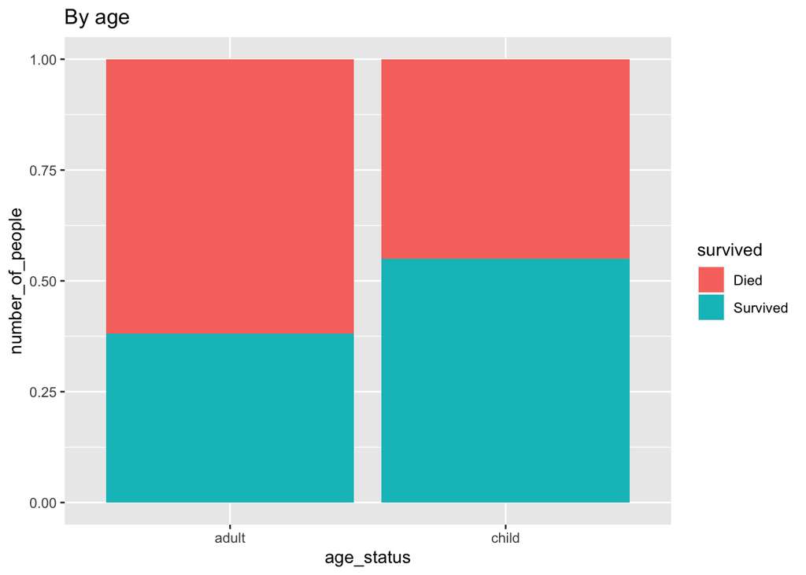

```r
# By child/adult
titanic_clean %>%
  group_by(survived, age_status) %>%
summarise(number_of_people = n()) %>%
  ggplot(aes(x = age_status, y = number_of_people, fill = survived)) +
  geom_col(position = "fill") +
  labs(title = "By age")
```

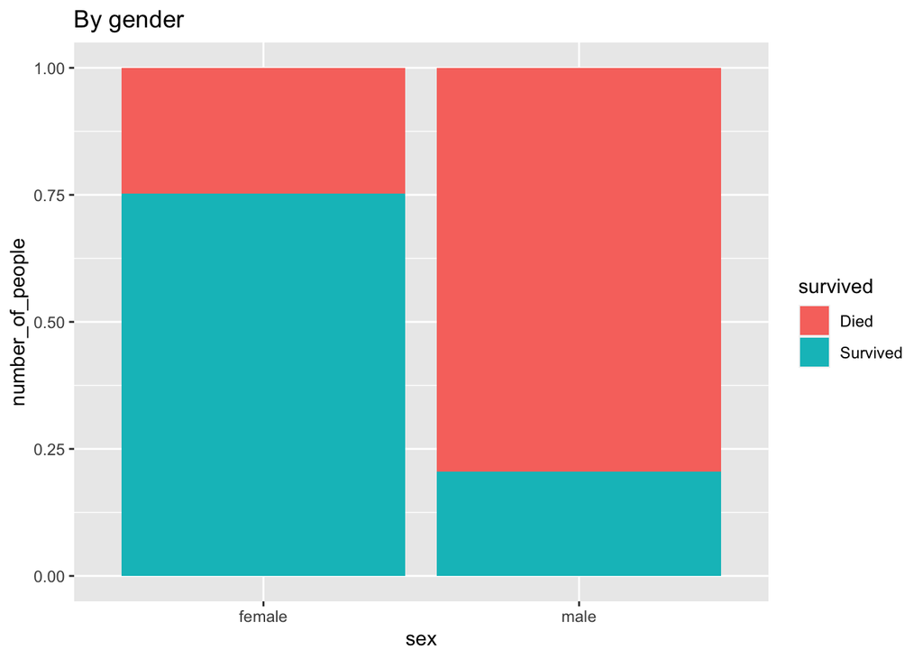

```r
# By gender
titanic_clean %>%
  group_by(survived, sex) %>%
summarise(number_of_people = n()) %>%
  ggplot(aes(x = sex, y = number_of_people, fill = survived)) +
  geom_col(position = "fill") +
  labs(title = "By gender")
```

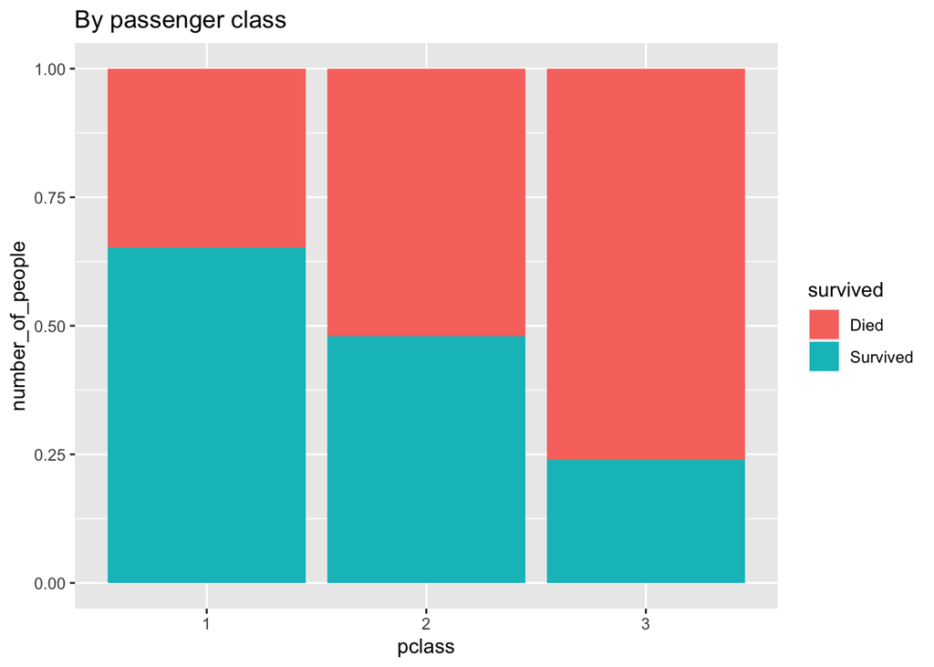

```r
# By passenger class
titanic_clean %>%
  group_by(survived, pclass) %>%
summarise(number_of_people = n()) %>%
  ggplot(aes(x = pclass, y = number_of_people, fill = survived)) +
  geom_col(position = "fill") +
  labs(title = "By passenger class")
```

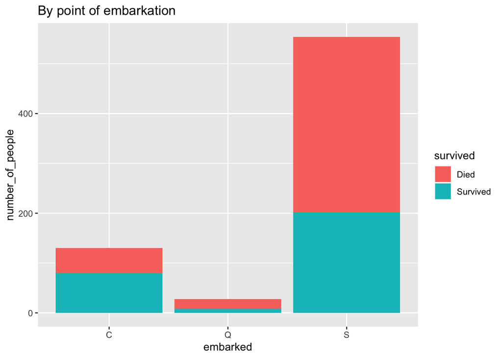

```r
# By embarkation point
titanic_clean %>%
  group_by(survived, embarked) %>%
summarise(number_of_people = n()) %>%
  ggplot(aes(x = embarked, y = number_of_people, fill = survived)) +
  geom_col() +
  labs(title = "By point of embarkation")
```

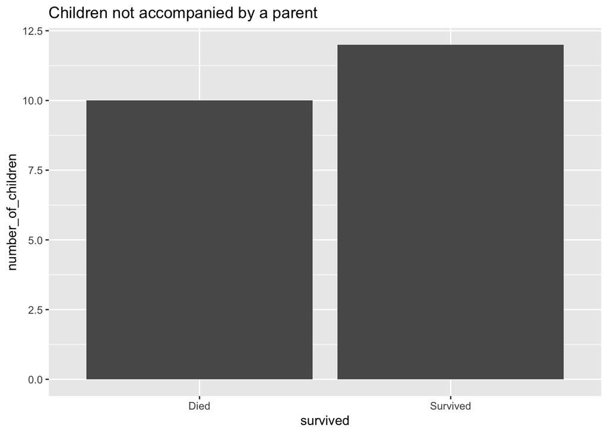

```r
# Children who were not accompanied by a parent
titanic_clean %>%
  filter(age_status == "child") %>%
  filter(parch == "0") %>%
  group_by(survived) %>%
summarise(number_of_children = n()) %>%
  ggplot(aes(x = survived, y = number_of_children)) +
  geom_col() +
  labs(title = "Children not accompanied by a parent")
```

## Model

### Create test/train datasets

```r
# Total number of rows
n_data <- nrow(titanic_clean)

# Select 20%  sample
test_index <- sample(1:n_data, size = n_data * 0.2)

# Create test set
titanic_test <- slice(titanic_clean, test_index)

# Create training set
titanic_train <- slice(titanic_clean, -test_index)
```

## Check test/train have similar proportions

Both have roughly a 40/60 split for the number of people who survived the disaster.

```r
titanic_test %>%
  tabyl(survived)
```

```
##  survived  n   percent
##      Died 80 0.5633803
##  Survived 62 0.4366197
```

```r
titanic_train %>%
  tabyl(survived)
```

```
##  survived   n   percent
##      Died 344 0.6035088
##  Survived 226 0.3964912
```

## Build tree model using training dataset

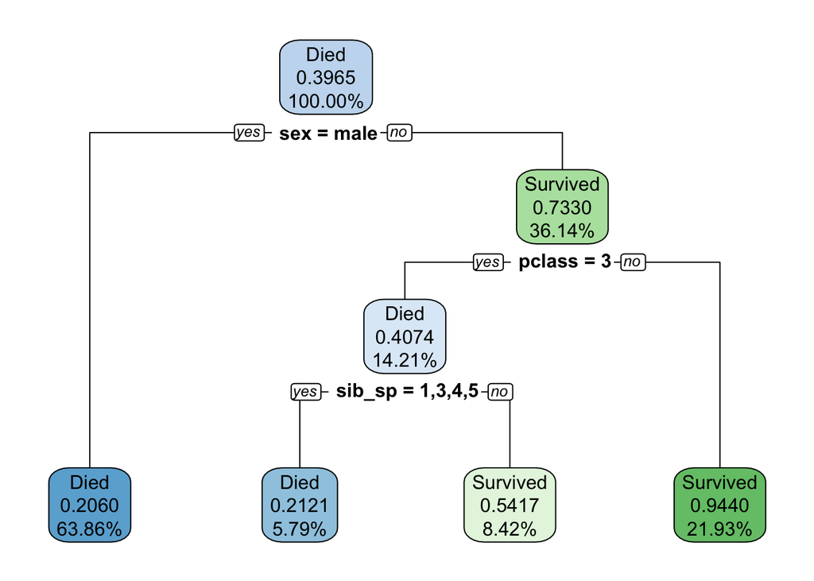

```r
titanic_fit <- rpart(
  formula = survived ~ .,
  data = titanic_train,
  method = 'class'
)

rpart.plot(titanic_fit,
           yesno = 2,
           fallen.leaves = TRUE,
           faclen = 6,
           digits = 4)
```

## Screenshot of the model and notes

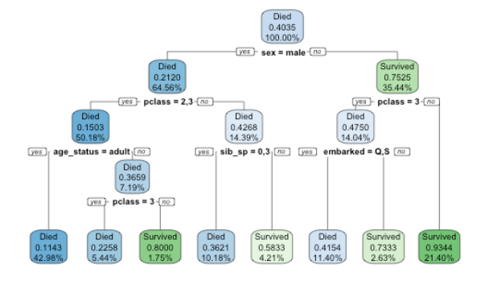

I’m not really sure how to interpret the data in the decision tree so I’ll leave it there and check at review.